# Hatton Assignment 9

## Grad School Admissions Data Report

### Setup:

```r
library(tidyverse)
library(GGally)
library(easystats)
library(MASS)
library(modelr)
```

### The Data:

```r
glimpse(df)
```

```
## Rows: 400
## Columns: 4
## $ admit <lgl> FALSE, TRUE, TRUE, TRUE, FALSE, TRUE, TRUE, FALSE, TRUE, FALSE, …
## $ gre   <dbl> 380, 660, 800, 640, 520, 760, 560, 400, 540, 700, 800, 440, 760,…
## $ gpa   <dbl> 3.61, 3.67, 4.00, 3.19, 2.93, 3.00, 2.98, 3.08, 3.39, 3.92, 4.00…
## $ rank  <dbl> 3, 3, 1, 4, 4, 2, 1, 2, 3, 2, 4, 1, 1, 2, 1, 3, 4, 3, 2, 1, 3, 2…
```

### Visualizing the Data:

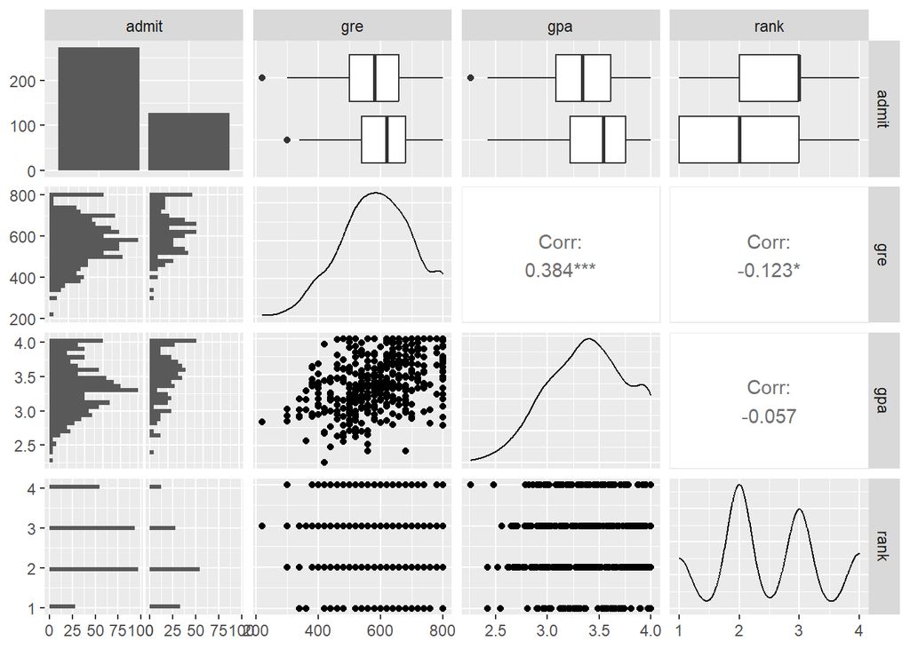

```r
ggpairs(df)
```

There seems to be a decently significant correlation between GRE and GPA, and the boxplot showing the interaction between rank and admission suggests that rank may influence grad school admission.

The following violin plots help to better see relationships between some of the variables. This plot below shows admittance based upon gpa, faceted by rank:

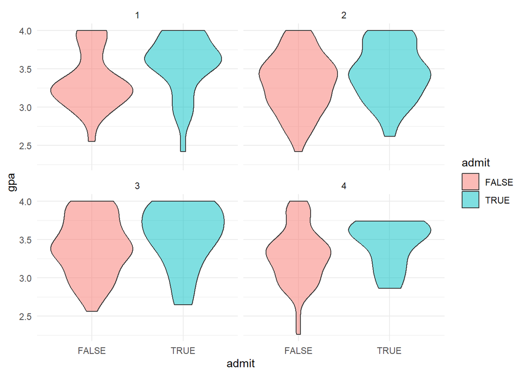

```r
df %>%
  ggplot(aes(x = admit,
             y = gpa,
             fill = admit)) +
  geom_violin(alpha = 0.5) +
  facet_wrap(~rank) +
  theme_minimal()
```

This plot shows admittance based upon gre score, faceted by rank:

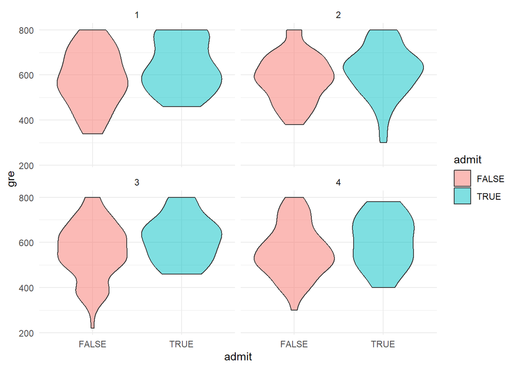

```r
df %>%
  ggplot(aes(x = admit,
             y = gre,
             fill = admit)) +
  geom_violin(alpha = 0.5) +
  facet_wrap(~rank) +
  theme_minimal()
```

### Modeling:

Now, I’ll define a few models with the 4 variables in the data set:

```r
names(df)
```

```
## [1] "admit" "gre"   "gpa"   "rank"
```

```r
mod1 <- glm(data = df,
            formula = admit ~ gre + gpa,
            family = "binomial")

mod2 <- glm(data = df,
            formula = admit ~ gre * gpa,
            family = "binomial")

mod3 <- glm(data = df,
            formula = admit ~ gre + gpa + rank,
            family = "binomial")

mod4 <- glm(data = df,
            formula = admit ~ gre * gpa + rank,
            family = "binomial")

mod5 <- glm(data = df,
            formula = admit ~ gre * gpa * rank,
            family = "binomial")
```

While there’s not a whole lot of ways to make a model with 4 total variables overly complex, I’m going to use stepwise AIC to make one final model:

```r
step <- stepAIC(mod5)
```

I can then view the formula and assign it to my model:

```r
step$formula
```

```
## admit ~ gre + gpa + rank + gre:gpa
```

```r
mod6 <- glm(data = df,
          formula = step$formula,
          family = "binomial")
```

Now, I’ll compare the performance of the six models:

```r
comps <- compare_performance(mod1, mod2, mod3, mod4, mod5, mod6, rank = TRUE)
```

```
## Following indices with missing values are not used for ranking: Sigma
```

```r
comps
```

```
## # Comparison of Model Performance Indices
##
## Name | Model | Tjur's R2 |  RMSE | Sigma | Log_loss | Score_log | Score_spherical |   PCP | AIC weights | AICc weights | BIC weights | Performance-Score
## --------------------------------------------------------------------------------------------------------------------------------------------------------
## mod4 |   glm |     0.105 | 0.440 | 1.000 |    0.571 |   -50.481 |           0.004 | 0.612 |       0.368 |        0.367 |       0.146 |            61.76%
## mod6 |   glm |     0.105 | 0.440 | 1.000 |    0.571 |   -50.481 |           0.004 | 0.612 |       0.368 |        0.367 |       0.146 |            61.76%
## mod3 |   glm |     0.099 | 0.442 | 1.000 |    0.574 |   -50.496 |           0.004 | 0.609 |       0.241 |        0.247 |       0.707 |            56.90%
## mod5 |   glm |     0.106 | 0.440 | 1.000 |    0.570 |   -50.593 |           0.005 | 0.613 |       0.022 |        0.020 |    2.18e-05 |            45.69%
## mod2 |   glm |     0.052 | 0.453 | 1.000 |    0.597 |   -48.633 |           0.004 | 0.589 |    2.43e-05 |     2.48e-05 |    7.11e-05 |            32.15%
## mod1 |   glm |     0.047 | 0.455 | 1.000 |    0.600 |   -48.679 |           0.004 | 0.587 |    1.90e-05 |     1.98e-05 |    4.09e-04 |            27.45%
```

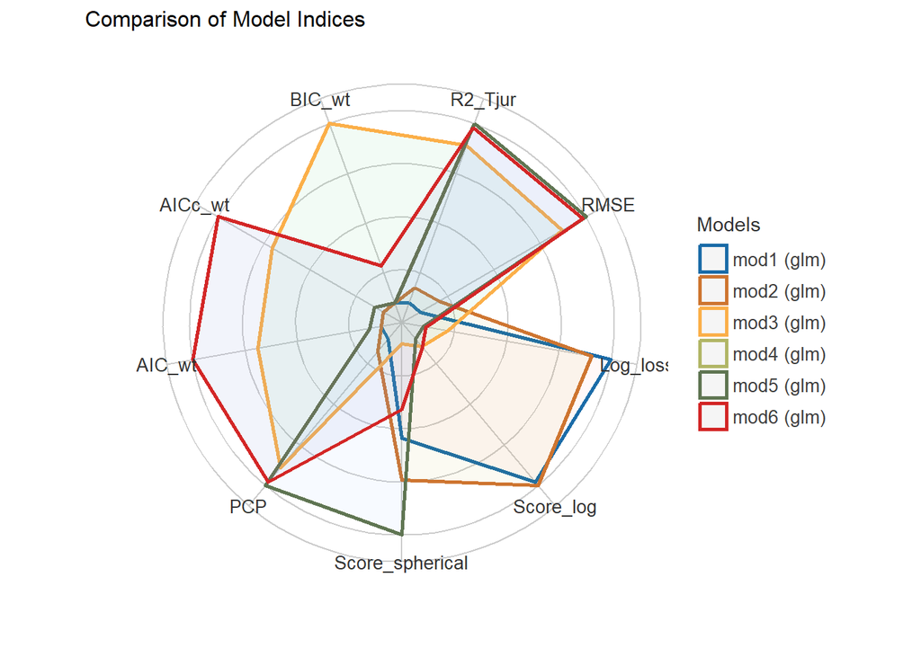

```r
comps %>% plot()
```

Mod4 and mod6 provide the same results, with a performance score of 61.76%, which is not phenomenally accurate.

### Predictions:

This violin plot shows the distribution of predicted probabilities of admission, which illustrates that none of the models are doing a particulary good job.

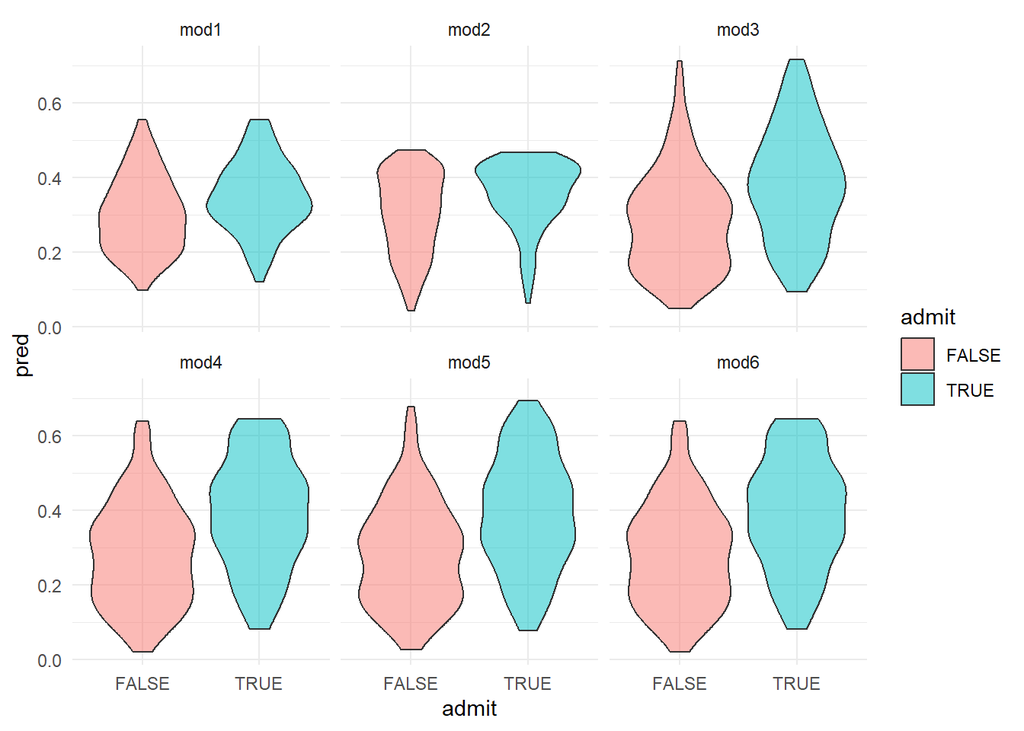

```r
df %>%
  gather_predictions(mod1, mod2, mod3, mod4, mod5, mod6, type = "response") %>%
  ggplot(aes(x = admit,
             y = pred,
             fill = admit)) +
  geom_violin(alpha = 0.5) +
  facet_wrap(~model) +
  theme_minimal()
```

### Conclusions:

There is not enough information to build a reliable model, given that the use of all variables maxed out reliability at just above 60%. The best indicator seemed to be the rank of the school one went to for their undergraduate in combination with both a higher gre score and a higher gpa.